# 07_EDA03_feature_screening

Yiwen Xiang

This file screens the complete Wave 11 candidate feature set after base and additional features have been merged. Features are screened by missingness, respondent-level missingness, and sparse categorical distributions before the final modelling dataset is saved.

# 1 1. Setup

# 2 2. Load merged candidate feature data

```r
data11_ml_pre_screening <- readRDS(
  file.path(processed_path, "07_wave11_ml_candidate_features_pre_screening.rds")
)

candidate_features_pre_screening <- readRDS(
  file.path(processed_path, "07_candidate_features_pre_screening.rds")
)

id_vars <- c("idauniq", "idahhw11", "perid")
outcome_vars <- c("casp19_total", "qol_status")

dim(data11_ml_pre_screening)
```

```
## [1] 5314   57
```

```r
length(candidate_features_pre_screening)
```

```
## [1] 52
```

The merged candidate dataset contains the three identifier columns, two outcome-related columns, and all candidate predictors assembled from base and additional features.

# 3 3. Outcome checks

```r
casp19_summary <- data11_ml_pre_screening %>%
  summarise(
    n = n(),
    mean = round(mean(casp19_total, na.rm = TRUE), 2),
    sd = round(sd(casp19_total, na.rm = TRUE), 2),
    median = round(median(casp19_total, na.rm = TRUE), 2),
    q1 = round(quantile(casp19_total, 0.25, na.rm = TRUE), 2),
    q3 = round(quantile(casp19_total, 0.75, na.rm = TRUE), 2),
    min = min(casp19_total, na.rm = TRUE),
    max = max(casp19_total, na.rm = TRUE)
  )

casp19_summary
```

```
## # A tibble: 1 × 8
##       n  mean    sd median    q1    q3   min   max
##   <int> <dbl> <dbl>  <dbl> <dbl> <dbl> <dbl> <dbl>
## 1  5314  41.1  9.43     43    35    48     2    57
```

```r
qol_distribution <- data11_ml_pre_screening %>%
  count(qol_status, name = "n") %>%
  mutate(percent = round(n / sum(n) * 100, 2))

qol_distribution
```

```
## # A tibble: 2 × 3
##   qol_status      n percent
##   <fct>       <int>   <dbl>
## 1 Non-low QoL  3970    74.7
## 2 Low QoL      1344    25.3
```

# 4 4. Screen features by missingness

All base and additional candidate features were screened together. Candidate features with more than 20% missingness were excluded before distribution checks.

```r
summarise_missingness <- function(data, variables) {
  n_total <- nrow(data)

  data %>%
    select(all_of(variables)) %>%
    summarise(across(everything(), ~ sum(is.na(.x)))) %>%
    pivot_longer(
      cols = everything(),
      names_to = "variable",
      values_to = "n_missing"
    ) %>%
    mutate(
      n_total = n_total,
      n_valid = n_total - n_missing,
      missing_percent = round(n_missing / n_total * 100, 2)
    ) %>%
    select(variable, n_total, n_missing, n_valid, missing_percent) %>%
    arrange(desc(missing_percent), variable)
}

candidate_missingness_pre_screening <- summarise_missingness(
  data11_ml_pre_screening,
  candidate_features_pre_screening
)

candidate_missingness_pre_screening
```

```
## # A tibble: 52 × 5
##    variable                   n_total n_missing n_valid missing_percent
##    <chr>                        <int>     <int>   <int>           <dbl>
##  1 memory_score                  5314      5314       0          100
##  2 stroke                        5314      5080     234           95.6
##  3 volunteering_participation    5314      3348    1966           63
##  4 hypertension_status           5314      3051    2263           57.4
##  5 hypertension                  5314      2885    2429           54.3
##  6 receiving_help_count          5314      2627    2687           49.4
##  7 fall_injury_status            5314      1167    4147           22.0
##  8 fall_status                   5314      1167    4147           22.0
##  9 bmi_new                       5314      1092    4222           20.6
## 10 smoking_status                5314       502    4812            9.45
## # ℹ 42 more rows
```

```r
# export_xlsx(candidate_missingness_pre_screening, "07_candidate_missingness_pre_screening.xlsx", output_path)
```

```r
high_missing_candidate_vars <- candidate_missingness_pre_screening %>%
  filter(missing_percent > 20) %>%
  pull(variable)

high_missing_candidate_vars
```

```
## [1] "memory_score"               "stroke"
## [3] "volunteering_participation" "hypertension_status"
## [5] "hypertension"               "receiving_help_count"
## [7] "fall_injury_status"         "fall_status"
## [9] "bmi_new"
```

```r
data11_ml_feature_screened <- data11_ml_pre_screening %>%
  select(-any_of(high_missing_candidate_vars))

candidate_features_screened <- setdiff(
  candidate_features_pre_screening,
  high_missing_candidate_vars
)

length(candidate_features_screened)
```

```
## [1] 43
```

After high-missingness features were excluded, `chronic_disease_count` was constructed from the seven chronic disease indicators retained for this purpose: arthritis, diabetes, cardiovascular disease, cancer, chronic lung disease/COPD, dementia/Alzheimer’s disease, and asthma.

```r
chronic_disease_vars <- c(
  "arthritis",
  "diabetes",
  "cvd",
  "cancer",
  "chronic_lung_disease",
  "dementia_alzheimers",
  "asthma"
)

missing_chronic_vars <- setdiff(
  chronic_disease_vars,
  names(data11_ml_feature_screened)
)

if (length(missing_chronic_vars) > 0) {
  stop(
    "The following chronic disease variables are not available after missingness screening: ",
    paste(missing_chronic_vars, collapse = ", ")
  )
}

data11_ml_feature_screened <- data11_ml_feature_screened %>%
  mutate(
    chronic_disease_count = rowSums(
      across(
        all_of(chronic_disease_vars),
        ~ .x == "Yes"
      ),
      na.rm = TRUE
    ),
    chronic_disease_count = if_else(
      if_all(all_of(chronic_disease_vars), is.na),
      NA_integer_,
      as.integer(chronic_disease_count)
    )
  )

candidate_features_screened <- c(
  candidate_features_screened,
  "chronic_disease_count"
)

candidate_features_screened <- unique(candidate_features_screened)

length(candidate_features_screened)
```

```
## [1] 44
```

# 5 5. Screen respondents by candidate-feature missingness

Respondent-level missingness was checked after high-missingness features had been removed. Respondents with more than 20% missing values across the screened candidate features were excluded before feature distribution checks.

```r
respondent_missingness <- data11_ml_feature_screened %>%
  mutate(
    n_missing_candidate_features =
      rowSums(is.na(across(all_of(candidate_features_screened)))),
    missing_candidate_percent =
      round(
        n_missing_candidate_features /
          length(candidate_features_screened) * 100,
        2
      )
  ) %>%
  select(
    all_of(id_vars),
    n_missing_candidate_features,
    missing_candidate_percent
  )

respondent_missingness %>%
  count(n_missing_candidate_features, missing_candidate_percent, sort = TRUE)
```

```
## # A tibble: 10 × 3
##    n_missing_candidate_features missing_candidate_percent     n
##                           <dbl>                     <dbl> <int>
##  1                            0                      0     3440
##  2                            1                      2.27  1412
##  3                            2                      4.55   326
##  4                            3                      6.82    82
##  5                            4                      9.09    20
##  6                            6                     13.6     11
##  7                            5                     11.4      9
##  8                            7                     15.9      7
##  9                            8                     18.2      6
## 10                           24                     54.6      1
```

```r
high_missing_respondent_ids <- respondent_missingness %>%
  filter(missing_candidate_percent > 20) %>%
  pull(idauniq)

respondent_missingness %>%
  filter(idauniq %in% high_missing_respondent_ids)
```

```
## # A tibble: 1 × 5
##   idauniq idahhw11 perid n_missing_candidate_features missing_candidate_percent
##     <dbl>    <dbl> <dbl>                        <dbl>                     <dbl>
## 1  118303   113653     1                           24                      54.6
```

```r
data11_ml_screened <- data11_ml_feature_screened %>%
  filter(!idauniq %in% high_missing_respondent_ids)

dim(data11_ml_screened)
```

```
## [1] 5313   49
```

# 6 6. Check feature distributions

```r
continuous_vars_screened <- data11_ml_screened %>%
  select(all_of(candidate_features_screened)) %>%
  select(where(is.numeric)) %>%
  names()

continuous_summary_screened <- purrr::map_dfr(
  continuous_vars_screened,
  function(v) {
    x <- data11_ml_screened[[v]]

    tibble(
      variable = v,
      n_non_missing = sum(!is.na(x)),
      n_missing = sum(is.na(x)),
      missing_percent = round(mean(is.na(x)) * 100, 2),
      mean = round(mean(x, na.rm = TRUE), 2),
      median = round(median(x, na.rm = TRUE), 2),
      sd = round(sd(x, na.rm = TRUE), 2),
      min = min(x, na.rm = TRUE),
      q1 = round(quantile(x, 0.25, na.rm = TRUE), 2),
      q3 = round(quantile(x, 0.75, na.rm = TRUE), 2),
      max = max(x, na.rm = TRUE)
    )
  }
)

continuous_summary_screened
```

```
## # A tibble: 15 × 11
##    variable     n_non_missing n_missing missing_percent  mean median    sd   min
##    <chr>                <int>     <int>           <dbl> <dbl>  <dbl> <dbl> <dbl>
##  1 age                   5313         0            0    68.7   68     9.67    51
##  2 adl_count             5313         0            0     0.35   0     0.97     0
##  3 iadl_count            5313         0            0     0.38   0     1.02     0
##  4 mobility_co…          5313         0            0     1.7    0     2.46     0
##  5 cesd_score            5251        62            1.17  1.42   1     1.89     0
##  6 loneliness_…          5262        51            0.96  4.19   3     1.56     3
##  7 social_part…          5115       198            3.73  1.42   1     1.38     0
##  8 social_rela…          5303        10            0.19  3.23   3.25  0.44     1
##  9 orientation…          5313         0            0     3.78   4     0.59     0
## 10 subjective_…          5120       193            3.63 63.3   65    17.0      5
## 11 anxiety_sco…          5134       179            3.37  3.33   2     4.45     0
## 12 objective_m…          5210       103            1.94 11.2   11     3.42     0
## 13 self_rated_…          5284        29            0.55  2.9    3     0.92     1
## 14 memory_chan…          5283        30            0.56  1.62   2     0.52     1
## 15 chronic_dis…          5313         0            0     1.07   1     1.05     0
## # ℹ 3 more variables: q1 <dbl>, q3 <dbl>, max <dbl>
```

```r
categorical_vars_screened <- data11_ml_screened %>%
  select(all_of(candidate_features_screened)) %>%
  select(where(~ is.factor(.x) || is.character(.x))) %>%
  names()

categorical_distribution_screened <- data11_ml_screened %>%
  select(all_of(categorical_vars_screened)) %>%
  mutate(across(everything(), as.character)) %>%
  pivot_longer(
    cols = everything(),
    names_to = "variable",
    values_to = "level"
  ) %>%
  count(variable, level, name = "n") %>%
  group_by(variable) %>%
  mutate(percent = round(n / sum(n) * 100, 2)) %>%
  ungroup() %>%
  arrange(variable, desc(n))

categorical_distribution_screened
```

```
## # A tibble: 100 × 4
##    variable                level                                n percent
##    <chr>                   <chr>                            <int>   <dbl>
##  1 alcohol_frequency_group Weekly                            2326   43.8
##  2 alcohol_frequency_group Monthly or less                   1043   19.6
##  3 alcohol_frequency_group No alcohol in last 12 months       794   14.9
##  4 alcohol_frequency_group Almost every day                   595   11.2
##  5 alcohol_frequency_group Rarely                             461    8.68
##  6 alcohol_frequency_group <NA>                                94    1.77
##  7 any_psychiatric_problem No psychiatric problem mentioned  5124   96.4
##  8 any_psychiatric_problem Psychiatric problem mentioned      189    3.56
##  9 any_received_care_help  No care/help received             4829   90.9
## 10 any_received_care_help  Received care/help                 484    9.11
## # ℹ 90 more rows
```

```r
rare_candidate_categories <- categorical_distribution_screened %>%
  filter(percent < 1) %>%
  arrange(variable, percent)

rare_candidate_categories
```

```
## # A tibble: 12 × 4
##    variable                 level                         n percent
##    <chr>                    <chr>                     <int>   <dbl>
##  1 caring_responsibilities  <NA>                         31    0.58
##  2 chronic_pain             <NA>                          3    0.06
##  3 cvd                      <NA>                          2    0.04
##  4 dementia_alzheimers      Yes                          21    0.4
##  5 dhwork                   <NA>                          5    0.09
##  6 hearing_problem          <NA>                          1    0.02
##  7 housing_tenure           <NA>                         27    0.51
##  8 housing_tenure           Other housing arrangement    43    0.81
##  9 marital_status           <NA>                          4    0.08
## 10 restless_sleep           <NA>                         35    0.66
## 11 self_rated_health        <NA>                          1    0.02
## 12 unmet_personal_care_need Unmet personal care need     10    0.19
```

Categories below 1% were reviewed because very small categories may be unstable in model training. Three feature-level decisions were made after this review.

First, the `Yes` category for `dementia_alzheimers` included very few respondents. Because `dementia_alzheimers` is a binary disease indicator, its categories directly represent disease status (`Yes` vs `No`). Merging the rare `Yes` category with `No` would remove the clinical meaning of the variable and incorrectly classify respondents with dementia/Alzheimer’s disease as not having the condition. The disease information is already retained through `chronic_disease_count`, so `dementia_alzheimers` was removed as a standalone candidate feature.

Second, the `Unmet personal care need` category in `unmet_personal_care_need` was very rare. Because this is also a binary indicator, merging the positive category with the negative category would change the meaning of the variable and misclassify respondents with unmet needs. Therefore, `unmet_personal_care_need` was removed as a standalone candidate feature.

Third, `Other housing arrangement` in `housing_tenure` accounted for less than 1% of the screened sample, so it was combined with `Rent` as `Rent/other arrangement`.

```r
rare_category_feature_exclusions <- tibble::tribble(
  ~variable, ~decision, ~reason,
  "dementia_alzheimers", "Excluded from final candidate predictors", "The positive category was below 1%, and the disease information is retained in chronic_disease_count.",
  "unmet_personal_care_need", "Excluded from final candidate predictors", "The positive category was below 1%, and the binary indicator could not be meaningfully merged."
)

rare_category_feature_exclusions
```

```
## # A tibble: 2 × 3
##   variable                 decision                                 reason
##   <chr>                    <chr>                                    <chr>
## 1 dementia_alzheimers      Excluded from final candidate predictors The positiv…
## 2 unmet_personal_care_need Excluded from final candidate predictors The positiv…
```

```r
data11_ml_screened <- data11_ml_screened %>%
  select(-any_of(c("dementia_alzheimers", "unmet_personal_care_need"))) %>%
  mutate(
    housing_tenure = case_when(
      housing_tenure == "Own outright" ~ "Own outright",
      housing_tenure == "Mortgage/shared ownership" ~ "Mortgage/shared ownership",
      housing_tenure %in% c("Rent", "Other housing arrangement") ~
        "Rent/other arrangement",
      is.na(housing_tenure) ~ NA_character_,
      TRUE ~ as.character(housing_tenure)
    ),
    housing_tenure = factor(
      housing_tenure,
      levels = c(
        "Own outright",
        "Mortgage/shared ownership",
        "Rent/other arrangement"
      )
    )
  )

candidate_features_screened <- setdiff(
  candidate_features_screened,
  c("dementia_alzheimers", "unmet_personal_care_need")
)

candidate_features_screened <- intersect(
  candidate_features_screened,
  names(data11_ml_screened)
)
```

```r
categorical_distribution_after_recode <- data11_ml_screened %>%
  select(all_of(candidate_features_screened)) %>%
  select(where(~ is.factor(.x) || is.character(.x))) %>%
  mutate(across(everything(), as.character)) %>%
  pivot_longer(
    cols = everything(),
    names_to = "variable",
    values_to = "level"
  ) %>%
  count(variable, level, name = "n") %>%
  group_by(variable) %>%
  mutate(percent = round(n / sum(n) * 100, 2)) %>%
  ungroup() %>%
  arrange(variable, desc(n))

categorical_distribution_after_recode %>%
  filter(variable == "housing_tenure")
```

```
## # A tibble: 4 × 4
##   variable       level                         n percent
##   <chr>          <chr>                     <int>   <dbl>
## 1 housing_tenure Own outright               3790   71.3
## 2 housing_tenure Mortgage/shared ownership   752   14.2
## 3 housing_tenure Rent/other arrangement      744   14
## 4 housing_tenure <NA>                         27    0.51
```

# 7 7. Save final Wave 11 modelling data

```r
missingness_exclusion_decisions <- tibble(
  variable = high_missing_candidate_vars,
  decision = "Excluded from final candidate predictors",
  reason = "Missingness was greater than 20% in the merged candidate feature set."
)

predictor_screening_decisions <- bind_rows(
  missingness_exclusion_decisions,
  rare_category_feature_exclusions
)

print(predictor_screening_decisions, n = Inf)
```

```
## # A tibble: 11 × 3
##    variable                   decision                                 reason
##    <chr>                      <chr>                                    <chr>
##  1 memory_score               Excluded from final candidate predictors Missingn…
##  2 stroke                     Excluded from final candidate predictors Missingn…
##  3 volunteering_participation Excluded from final candidate predictors Missingn…
##  4 hypertension_status        Excluded from final candidate predictors Missingn…
##  5 hypertension               Excluded from final candidate predictors Missingn…
##  6 receiving_help_count       Excluded from final candidate predictors Missingn…
##  7 fall_injury_status         Excluded from final candidate predictors Missingn…
##  8 fall_status                Excluded from final candidate predictors Missingn…
##  9 bmi_new                    Excluded from final candidate predictors Missingn…
## 10 dementia_alzheimers        Excluded from final candidate predictors The posi…
## 11 unmet_personal_care_need   Excluded from final candidate predictors The posi…
```

```r
data11_ml <- data11_ml_screened %>%
  select(
    all_of(id_vars),
    all_of(outcome_vars),
    all_of(candidate_features_screened)
  )

candidate_features <- setdiff(
  names(data11_ml),
  c(id_vars, outcome_vars)
)

dim(data11_ml)
```

```
## [1] 5313   47
```

```r
length(candidate_features)
```

```
## [1] 42
```

```r
candidate_missingness <- summarise_missingness(data11_ml, candidate_features)

candidate_missingness
```

```
## # A tibble: 42 × 5
##    variable                   n_total n_missing n_valid missing_percent
##    <chr>                        <int>     <int>   <int>           <dbl>
##  1 smoking_status                5313       501    4812            9.43
##  2 internet_help_frequency       5313       399    4914            7.51
##  3 financial_difficulty          5313       357    4956            6.72
##  4 wealth_quintile               5313       225    5088            4.23
##  5 social_participation_count    5313       198    5115            3.73
##  6 subjective_social_status      5313       193    5120            3.63
##  7 anxiety_score                 5313       179    5134            3.37
##  8 objective_memory_score        5313       103    5210            1.94
##  9 alcohol_frequency_group       5313        94    5219            1.77
## 10 cesd_score                    5313        62    5251            1.17
## # ℹ 32 more rows
```

```r
continuous_vars <- data11_ml %>%
  select(all_of(candidate_features)) %>%
  select(where(is.numeric)) %>%
  names()

categorical_vars <- data11_ml %>%
  select(all_of(candidate_features)) %>%
  select(where(~ is.factor(.x) || is.character(.x))) %>%
  names()

continuous_summary <- continuous_summary_screened %>%
  filter(variable %in% continuous_vars)

categorical_distribution <- categorical_distribution_after_recode %>%
  filter(variable %in% categorical_vars)
```

```r
saveRDS(
  data11_ml,
  file.path(processed_path, "07_wave11_ml_data.rds")
)

saveRDS(
  candidate_features,
  file.path(processed_path, "07_candidate_features.rds")
)


message("Wave 11 final ML dataset and EDA summary have been saved.")
```

```
## Wave 11 final ML dataset and EDA summary have been saved.
```

```r
message("Saved: data/processed/07_wave11_ml_data.rds")
```

```
## Saved: data/processed/07_wave11_ml_data.rds
```

```r
message("Saved: data/processed/07_candidate_features.rds")
```

```
## Saved: data/processed/07_candidate_features.rds
```

# 8 8. Final sample age and sex distributions

The following plots describe the demographic composition of the final Wave 11 modelling dataset after feature and respondent screening.

```r
required_demographic_vars <- c("age", "sex")
missing_demographic_vars <- setdiff(required_demographic_vars, names(data11_ml))

if (length(missing_demographic_vars) > 0) {
  stop(
    "The following demographic variables are missing from data11_ml: ",
    paste(missing_demographic_vars, collapse = ", ")
  )
}
```

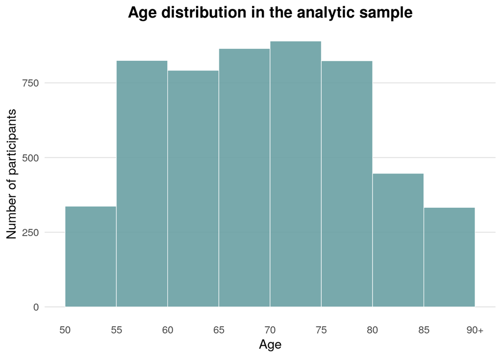

```r
age_distribution_plot <- data11_ml %>%
  filter(!is.na(age)) %>%
  ggplot(aes(x = age)) +
  geom_histogram(
    binwidth = 5,
    boundary = 50,
    closed = "left",
    fill = "#6aa0a3",
    color = "white",
    linewidth = 0.25,
    alpha = 0.9
  ) +
  scale_x_continuous(
    breaks = seq(50, 90, by = 5),
    labels = c(seq(50, 85, by = 5), "90+")
  ) +
  labs(
    title = "Age distribution in the analytic sample",
    x = "Age",
    y = "Number of participants"
  ) +
  theme_minimal(base_size = 13) +
  theme(
    plot.title = element_text(hjust = 0.5, face = "bold"),
    panel.grid.major.x = element_blank(),
    panel.grid.minor.x = element_blank(),
    panel.grid.major.y = element_line(color = "grey88", linewidth = 0.4),
    panel.grid.minor.y = element_blank(),
    panel.background = element_rect(fill = "white", color = NA),
    plot.background = element_rect(fill = "white", color = NA)
  )

age_distribution_plot
```

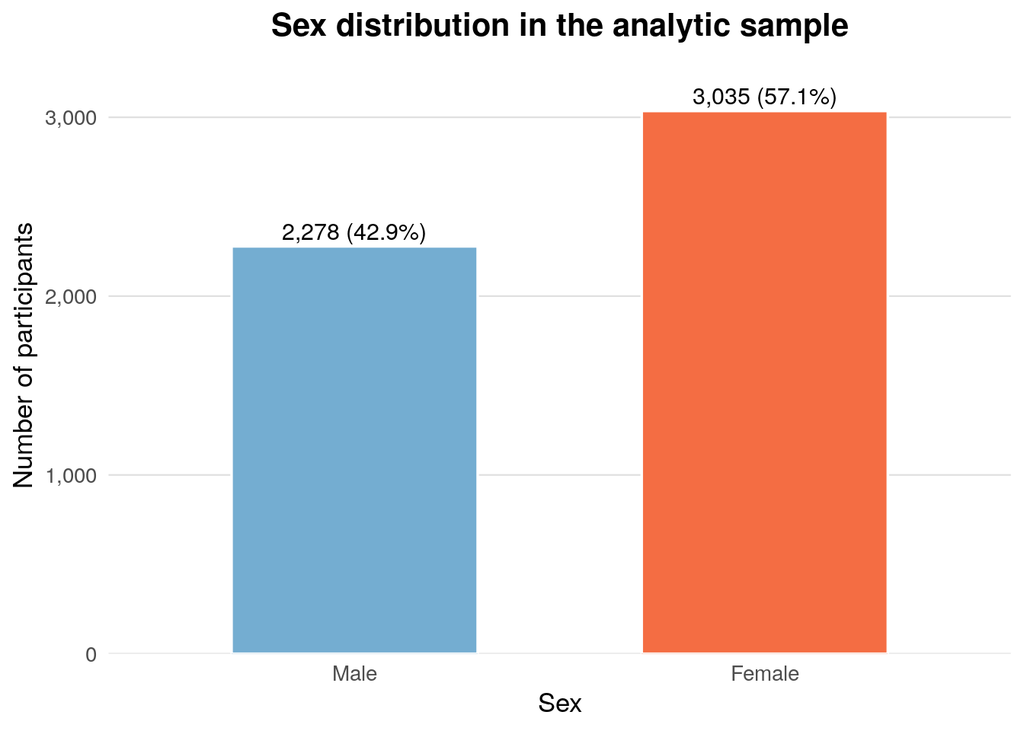

```r
sex_distribution_plot_data <- data11_ml %>%
  mutate(
    sex_plot = case_when(
      is.na(sex) ~ "Missing",
      TRUE ~ as.character(sex)
    ),
    sex_plot = factor(
      sex_plot,
      levels = c("Male", "Female", "Missing")
    )
  ) %>%
  count(sex_plot, name = "n") %>%
  mutate(
    percentage = n / sum(n) * 100,
    label = paste0(
      format(n, big.mark = ","),
      " (",
      round(percentage, 1),
      "%)"
    )
  )

sex_distribution_plot <- ggplot(
  sex_distribution_plot_data,
  aes(x = sex_plot, y = n, fill = sex_plot)
) +
  geom_col(width = 0.6, color = "white") +
  geom_text(
    aes(label = label),
    vjust = -0.4,
    size = 4
  ) +
  scale_fill_manual(
    values = c(
      "Male" = "#74ADD1",
      "Female" = "#F46D43",
      "Missing" = "#BDBDBD"
    )
  ) +
  scale_y_continuous(
    labels = scales::comma,
    expand = expansion(mult = c(0, 0.1))
  ) +
  labs(
    title = "Sex distribution in the analytic sample",
    x = "Sex",
    y = "Number of participants",
    fill = "Sex"
  ) +
  theme_minimal(base_size = 13) +
  theme(
    plot.title = element_text(hjust = 0.5, face = "bold"),
    legend.position = "none",
    panel.grid.major.x = element_blank(),
    panel.grid.minor.x = element_blank(),
    panel.grid.major.y = element_line(color = "grey88", linewidth = 0.4),
    panel.grid.minor.y = element_blank(),
    panel.background = element_rect(fill = "white", color = NA),
    plot.background = element_rect(fill = "white", color = NA)
  )

sex_distribution_plot
```

```r
ggsave(
  filename = file.path(picture_path, "07_final_sample_age_distribution.png"),
  plot = age_distribution_plot,
  width = 7,
  height = 4.5,
  dpi = 300
)

ggsave(
  filename = file.path(picture_path, "07_final_sample_sex_distribution.png"),
  plot = sex_distribution_plot,
  width = 6,
  height = 4.5,
  dpi = 300
)

message("Saved: pictures/07_final_sample_age_distribution.png")
```

```
## Saved: pictures/07_final_sample_age_distribution.png
```

```r
message("Saved: pictures/07_final_sample_sex_distribution.png")
```

```
## Saved: pictures/07_final_sample_sex_distribution.png
```